# diabetes_novo

Ana Sofia

02/12/2019

# Apresentação do caso de estudo

Este data set foi extraido no Kaggle, mas originalmente foi retirado do Instituto Nacional de Diabetes e Doenças Digestivas e Renais dos Estados Unidos. O objetivo deste conjunto de dados seria prever se um paciente tem ou não diabetes, baseado em determinadas medidas de diagnóstico incluídas no data set. Neste conjunto de dados estão presentes pacientes do género feminino com pelo menos 21 anos de idade e origem da povoação indigena Pima.

## Descrição dos dados

O dataset contém informações de 768 mulheres, das quais 268 mulheres foram diagnosticadas com diabetes. As informações disponíveis incluem 8 variáveis, tais como Idade, Número de gestações, Glicose, Insulina, etc. Uma descrição mais detalhada sobre as variáveis está exposta nos pontos abaixo. A variável de resposta no conjunto de dados é um classificador binário, *Outcome*, que indica se a pessoa foi diagnosticada com diabetes ou não.

- *Pregnancies*: Número de vezes que engravidou
- *Glucose*: Concentração de glicose no plasma durante 2 horas presente num teste de tolerância à glicose por via oral
- *BloodPressure*: Pressão sanguínea diastólica (mm Hg)
- *SkinThickness*: Espessura da dobra da pele do tríceps (mm)
- *Insulin*: Insulina sérica de 2 horas ($niu$U/ml)
- BMI: índice de massa gorda (weight in kg/(height in m)2)
- *DiabetesPedigreeFunction*: Função de heretiedade do diabetes (uma função que pontua a probabilidade de diabetes com base no histórico familiar)
- *Age*: Idade (anos)
- *Outcome*: Variável de classe (0 se não diabético, 1 se diabético)

| Nome da variável | Tipo de dados | Descrição da variável |
| --- | --- | --- |
| Pregnancies | integer | Número de vezes que engravidou |
| Glucose | integer | Concentração de glicose no plasma às 2 horas num teste oral de tolerância à glicose |
| BloodPressure | integer | Pressão sanguínea diastólica |
| SkinThickness | integer | Espessura da dobra da pele do tríceps |
| Insulin | integer | Insulina sérica de 2 horas (µU / ml) |
| BMI | numeric | índice de massa corporal |
| DiabetesPedigreeFunction | numeric | Síntese da história do Diabetes Mellitus em familiares |
| Age | integer | Idade (anos) |
| Outcome | integer | Ocorrência ou não da diabetes |

```r
#loira
#library(readr)
#diabetes <- read_csv("C:/Users/RP/Desktop/análise de clusters/TP2/diabetes.csv")
#View(diabetes)

#marcia
#library(readr)
#diabetes <- read_csv("C:/Users/marci.MARCIA.000/Downloads/diabetes.csv")
#View(diabetes)

#samuel

#celia
library(readr)
diabetes <- read_csv("diabetes.csv")
View(diabetes)
```

# Descrição das variáveis envolvidas

#### **Variável dependente**

Uma variável dependente é uma medida que dependerá do valor de outra(s) medida variável. Na base de dados apresentada, o resultado é considerada a variável binária dependente, uma vez que depende das restantes variáveis. Esta variável define se o paciente possuí ou não a doença diabetes.

```r
#variável dependente
resultado <- diabetes$Outcome
```

#### **Variáveis independentes**

Uma variável independente é uma medida que não depende de nenhuma outra medida, sendo que existem 8 variáveis deste tipo no modelo. Foram consideradas variáveis tais como o número de gravidezes, a concentração de glicose no plasma, a pressão sanguínea diastólica (mm Hg), a espessura da pele do trícepe (mm), o nível de insulina durante as 2 horas de teste (mu U/ml), o ´índice de massa corporal (peso (kg)/ altura (m)^2), a função de linhagem de diabetes e a idade em anos.

```r
#variáveis independentes
gravidez <- diabetes$Pregnancies
glicose <- diabetes$Glucose
pressaosangue <- diabetes$BloodPressure
espessurapele <- diabetes$SkinThickness
insulina <- diabetes$Insulin
imc <- diabetes$BMI
funcaogenetica <- diabetes$DiabetesPedigreeFunction
idade <- diabetes$Age
```

```r
resultado.f <- factor(resultado)

levels(resultado) <- c("Não", "Sim")

is.factor(resultado)
```

```
## [1] FALSE
```

```r
summary(resultado)
```

```
##    Min. 1st Qu.  Median    Mean 3rd Qu.    Max.
##   0.000   0.000   0.000   0.349   1.000   1.000
```

# Análise Descritiva

Utilizando a função “summary” verificamos o mínimo, máximo, a mediana e os quartis para cada variável em estudo.

```r
#summary dos dados
summary(diabetes)
```

```
##   Pregnancies        Glucose      BloodPressure    SkinThickness
##  Min.   : 0.000   Min.   :  0.0   Min.   :  0.00   Min.   : 0.00
##  1st Qu.: 1.000   1st Qu.: 99.0   1st Qu.: 62.00   1st Qu.: 0.00
##  Median : 3.000   Median :117.0   Median : 72.00   Median :23.00
##  Mean   : 3.845   Mean   :120.9   Mean   : 69.11   Mean   :20.54
##  3rd Qu.: 6.000   3rd Qu.:140.2   3rd Qu.: 80.00   3rd Qu.:32.00
##  Max.   :17.000   Max.   :199.0   Max.   :122.00   Max.   :99.00
##     Insulin           BMI        DiabetesPedigreeFunction      Age
##  Min.   :  0.0   Min.   : 0.00   Min.   :0.0780           Min.   :21.00
##  1st Qu.:  0.0   1st Qu.:27.30   1st Qu.:0.2437           1st Qu.:24.00
##  Median : 30.5   Median :32.00   Median :0.3725           Median :29.00
##  Mean   : 79.8   Mean   :31.99   Mean   :0.4719           Mean   :33.24
##  3rd Qu.:127.2   3rd Qu.:36.60   3rd Qu.:0.6262           3rd Qu.:41.00
##  Max.   :846.0   Max.   :67.10   Max.   :2.4200           Max.   :81.00
##     Outcome
##  Min.   :0.000
##  1st Qu.:0.000
##  Median :0.000
##  Mean   :0.349
##  3rd Qu.:1.000
##  Max.   :1.000
```

```r
table(resultado)
```

```
## resultado
##   0   1
## 500 268
```

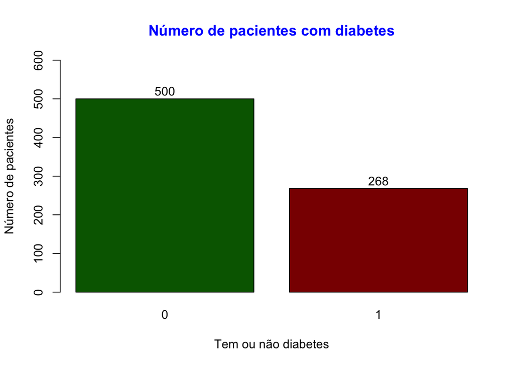

```r
resultado <- c(500, 268)
  bp <- barplot(resultado, main = "Número de pacientes com diabetes", ylab = "Número de pacientes", xlab = "Tem ou não diabetes", ylim = c(0,600), names.arg = c("0", "1"), col = c("darkgreen", "darkred"), col.main = "blue", horiz = FALSE)
text(bp,resultado+20,labels=as.character(resultado))
```

## Análise da variável “gravidez”

```r
table(gravidez)
```

```
## gravidez
##   0   1   2   3   4   5   6   7   8   9  10  11  12  13  14  15  17
## 111 135 103  75  68  57  50  45  38  28  24  11   9  10   2   1   1
```

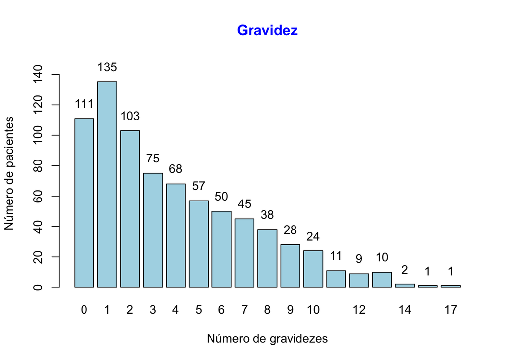

```r
grav <- c(111, 135,103,75,68,57,50,45,38,28,24,11,9,10,2,1,1)
 b <- barplot(grav,
 main = "Gravidez",
 xlab = "Número de gravidezes",
 ylab = "Número de pacientes",
 ylim = c(0,150),
 names.arg = c(0,1,2,3,4,5,6,7,8,9,10,11,12,13,14,15,17),
 col = c("lightblue"),
 col.main="blue",
 horiz = FALSE)
text(b,grav+10,labels=as.character(grav))
```

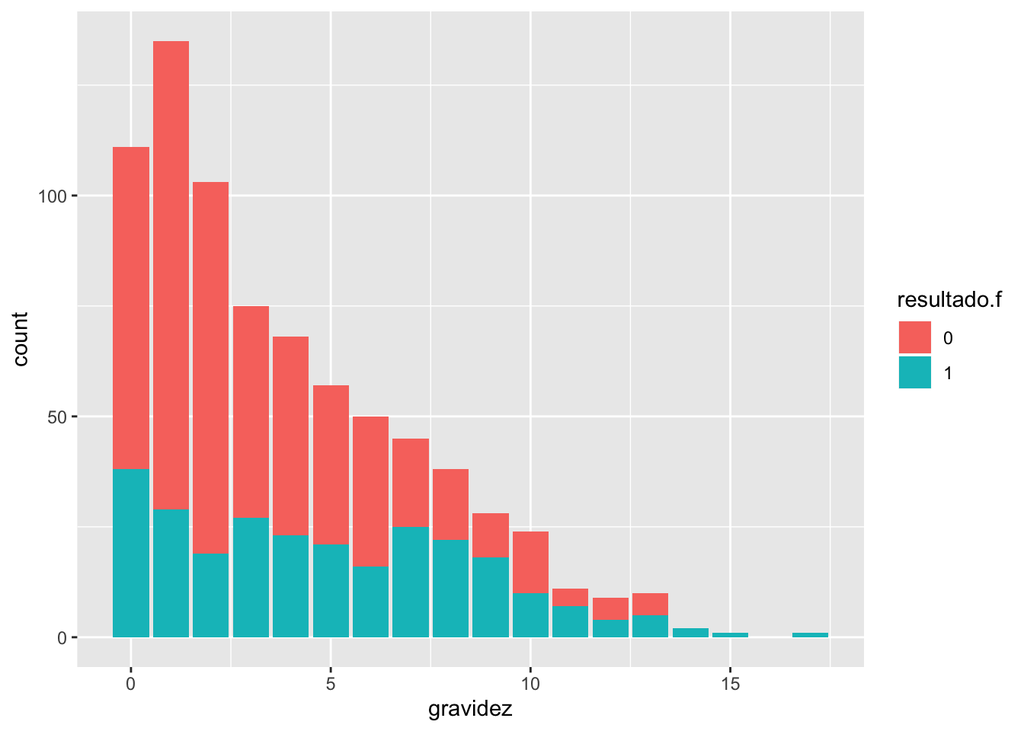

```r
library(ggplot2)
ggplot(diabetes, aes(x = gravidez, fill = resultado.f)) + geom_bar()
```

## Matriz de correlação

```r
library(corrplot)
matriz <- diabetes
res<- cor(matriz)

round(res,2)
```

```
##                          Pregnancies Glucose BloodPressure SkinThickness
## Pregnancies                     1.00    0.13          0.14         -0.08
## Glucose                         0.13    1.00          0.15          0.06
## BloodPressure                   0.14    0.15          1.00          0.21
## SkinThickness                  -0.08    0.06          0.21          1.00
## Insulin                        -0.07    0.33          0.09          0.44
## BMI                             0.02    0.22          0.28          0.39
## DiabetesPedigreeFunction       -0.03    0.14          0.04          0.18
## Age                             0.54    0.26          0.24         -0.11
## Outcome                         0.22    0.47          0.07          0.07
##                          Insulin  BMI DiabetesPedigreeFunction   Age
## Pregnancies                -0.07 0.02                    -0.03  0.54
## Glucose                     0.33 0.22                     0.14  0.26
## BloodPressure               0.09 0.28                     0.04  0.24
## SkinThickness               0.44 0.39                     0.18 -0.11
## Insulin                     1.00 0.20                     0.19 -0.04
## BMI                         0.20 1.00                     0.14  0.04
## DiabetesPedigreeFunction    0.19 0.14                     1.00  0.03
## Age                        -0.04 0.04                     0.03  1.00
## Outcome                     0.13 0.29                     0.17  0.24
##                          Outcome
## Pregnancies                 0.22
## Glucose                     0.47
## BloodPressure               0.07
## SkinThickness               0.07
## Insulin                     0.13
## BMI                         0.29
## DiabetesPedigreeFunction    0.17
## Age                         0.24
## Outcome                     1.00
```

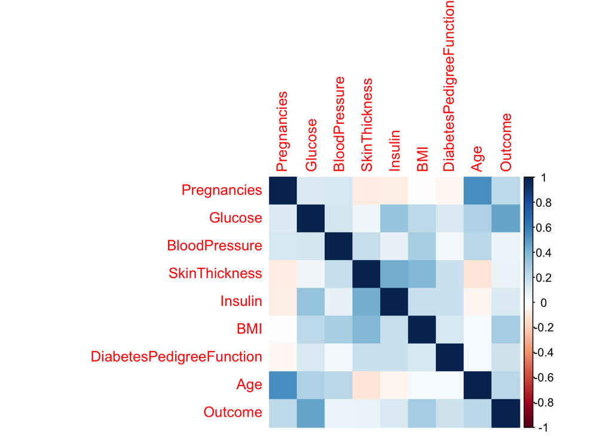

```r
corrplot(res, method = "color")
```

```r
library(Amelia)
sapply(diabetes, function (x) sum(is.na(x)))
```

```
##              Pregnancies                  Glucose            BloodPressure
##                        0                        0                        0
##            SkinThickness                  Insulin                      BMI
##                        0                        0                        0
## DiabetesPedigreeFunction                      Age                  Outcome
##                        0                        0                        0
```

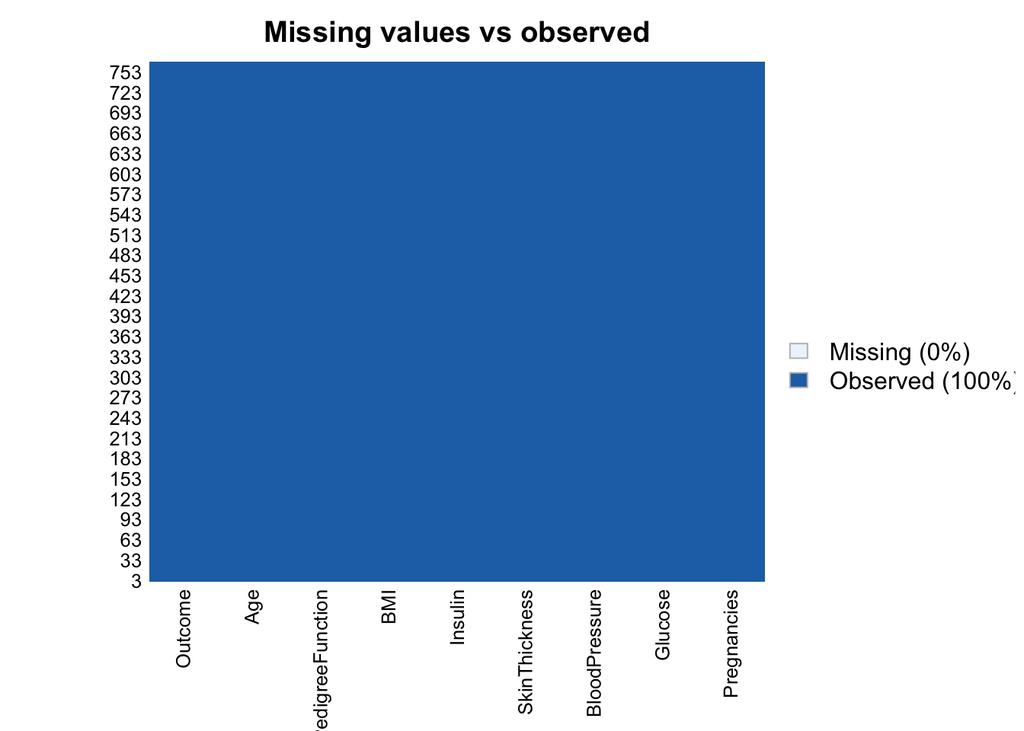

```r
#saber se existem missing values
data<- subset(diabetes,select=c(1,2,3,4,5,6,7,8,9))
missmap(data, main = "Missing values vs observed")
```

```r
library(caret)
# Prep Training e Test
set.seed(100)
trainDataIndex <- createDataPartition(diabetes$Outcome, p=0.7, list = F) # 70% training data
train <- diabetes[trainDataIndex, ]
test <- diabetes[-trainDataIndex, ]

#Modelo
model <- glm(Outcome~.,family=binomial(link='logit'),data=train)
summary(model)
```

```
##
## Call:
## glm(formula = Outcome ~ ., family = binomial(link = "logit"),
##     data = train)
##
## Deviance Residuals:
##     Min       1Q   Median       3Q      Max
## -2.4651  -0.7331  -0.4387   0.7856   2.7723
##
## Coefficients:
##                           Estimate Std. Error z value Pr(>|z|)
## (Intercept)              -7.630372   0.795902  -9.587  < 2e-16 ***
## Pregnancies               0.100671   0.038483   2.616   0.0089 **
## Glucose                   0.034576   0.004298   8.045 8.63e-16 ***
## BloodPressure            -0.014687   0.006007  -2.445   0.0145 *
## SkinThickness            -0.001808   0.008173  -0.221   0.8249
## Insulin                  -0.001383   0.001015  -1.363   0.1729
## BMI                       0.074435   0.017627   4.223 2.41e-05 ***
## DiabetesPedigreeFunction  0.788247   0.347752   2.267   0.0234 *
## Age                       0.019560   0.011049   1.770   0.0767 .
## ---
## Signif. codes:  0 '***' 0.001 '**' 0.01 '*' 0.05 '.' 0.1 ' ' 1
##
## (Dispersion parameter for binomial family taken to be 1)
##
##     Null deviance: 698.73  on 537  degrees of freedom
## Residual deviance: 523.73  on 529  degrees of freedom
## AIC: 541.73
##
## Number of Fisher Scoring iterations: 5
```

```r
yhat=fitted.values(model)
```

```r
anova(model, test="Chisq")
```

```
## Analysis of Deviance Table
##
## Model: binomial, link: logit
##
## Response: Outcome
##
## Terms added sequentially (first to last)
##
##
##                          Df Deviance Resid. Df Resid. Dev  Pr(>Chi)
## NULL                                       537     698.73
## Pregnancies               1   19.915       536     678.82 8.098e-06 ***
## Glucose                   1  122.461       535     556.36 < 2.2e-16 ***
## BloodPressure             1    1.157       534     555.20   0.28214
## SkinThickness             1    0.506       533     554.70   0.47706
## Insulin                   1    1.742       532     552.95   0.18693
## BMI                       1   20.362       531     532.59 6.408e-06 ***
## DiabetesPedigreeFunction  1    5.732       530     526.86   0.01666 *
## Age                       1    3.135       529     523.73   0.07664 .
## ---
## Signif. codes:  0 '***' 0.001 '**' 0.01 '*' 0.05 '.' 0.1 ' ' 1
```

```r
fitted.results <- predict(model,newdata=subset(test,select=c(1,2,3,4,5,6,7,8,9)),type='response')
fitted.results <- ifelse(fitted.results > 0.5,1,0)
misClasificError <- mean(fitted.results != test$Outcome)
print(paste('Accuracy',1-misClasificError))
```

```
## [1] "Accuracy 0.78695652173913"
```

```r
library(tidyverse)# for data manipulation
library(dlstats)    # for package download stats
library(pkgsearch)
library(ROCR)
```

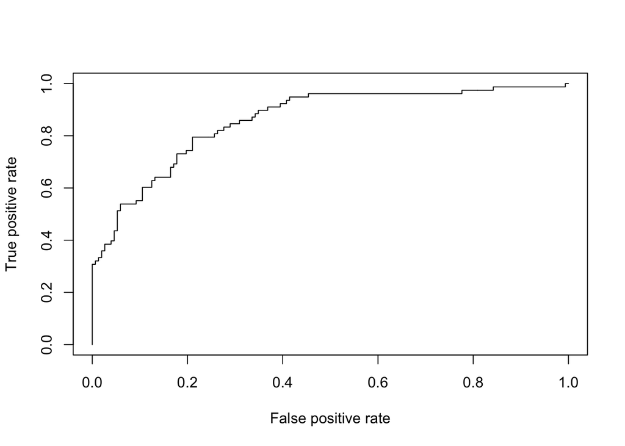

```r
p <- predict(model, newdata=subset(test,select=c(1,2,3,4,5,6,7,8,9)), type="response")
pr <- prediction(p, test$Outcome)
prf <- performance(pr, measure = "tpr", x.measure = "fpr")
plot(prf)
```

```r
auc <- performance(pr, measure = "auc")
auc <- auc@y.values[[1]]
auc
```

```
## [1] 0.8599022
```

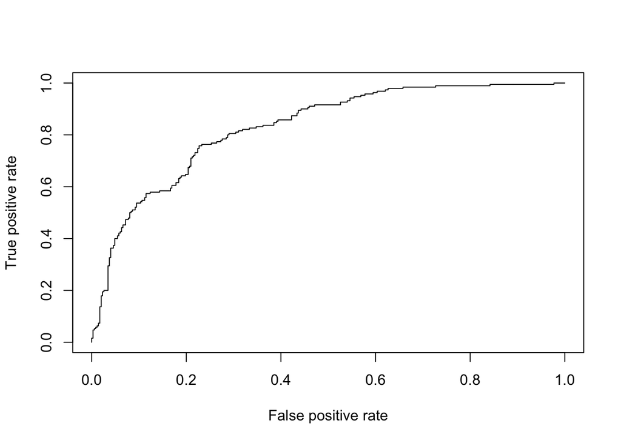

```r
#validação interna
library(yhat)
pr_i <- prediction(yhat, train$Outcome)
prf_i <- performance(pr_i, measure = "tpr", x.measure = "fpr")
plot(prf_i)
```